# IndexNumber: An R Package for Measuring the Evolution of Magnitudes

### Non-weighted complex index numbers in R

In this section, we illustrate the usage of *IndexNumber* to determine non-weighted complex index numbers.

As in its theoretical description, we take the example described in Table 6 to show its performance in practice. That table describes the unitary value of prices of several energy resources for the period 2005-2015. As we have mentioned, this data set is available in library *IndexNumber* under the name `ECResources` (in particular, from the second to the sixth column).

```r
> ECResources[,2:6]
   ElectricityPrice NaturalGasPrice LiquifiedGasPrice LiquifiedCombustiblesPrice SolidCombustiblesPrice
1              0.14            0.70              1.00                       0.69                   0.12
2              0.14            0.78              0.97                       0.66                   0.10
3              0.15            0.83              1.03                       0.81                   0.11
4              0.16            0.87              0.93                       0.68                   0.10
5              0.17            0.79              1.04                       0.72                   0.12
6              0.19            0.77              1.15                       0.91                   0.12
7              0.22            0.82              1.19                       0.96                   0.12
8              0.23            1.00              1.34                       0.99                   0.13
9              0.24            1.07              1.35                       0.89                   0.15
10             0.25            1.04              1.22                       0.77                   0.13
```

First, we describe the R procedures that provide the variations of a magnitude in time $t$ with respect to the base period by using non-weighted index numbers. For this purpose, we have to introduce the option `base="serie"`. Notice that all the values included in Table 8 were obtained by using the code in R that we show in the current section.

**Sauerbeck index in R**

Next, we determine the Sauerbeck index (@ref(eq:niSauerbeck)) in R software. To this aim, we use the corresponding function `aggregated.index.number()` by adding, as option, `type="arithmetic"`. Recall that it corresponds to an average by stages. In this case, we also include a graphical description of the joint evolution of prices in Figure 5 with `opt.plot=TRUE`, and a numerical summary of such magnitude (with `opt.summary=TRUE`).

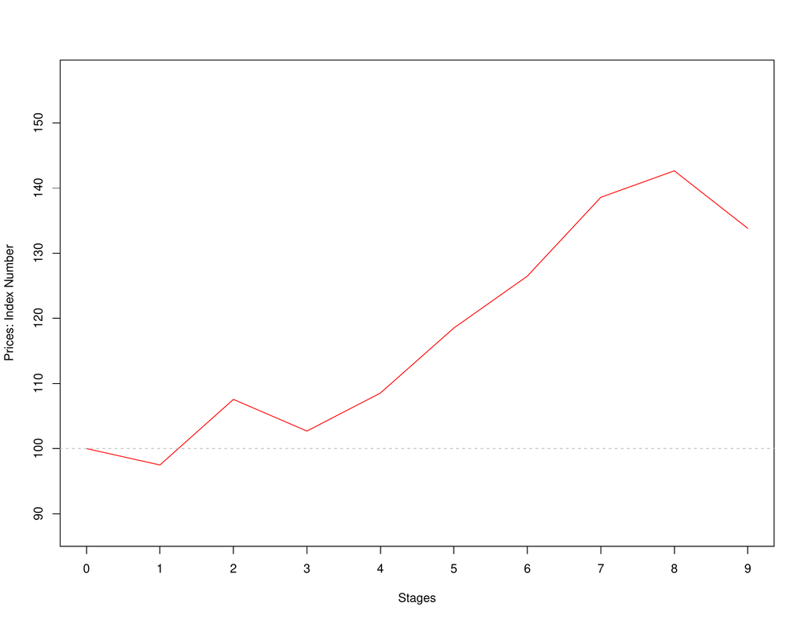

Figure 5: Sauerbeck index evolution for the prices of several energy resources for the period 2005-2015.

```r
> aggregated.index.number(ECResources[,2:6],base="serie",type="arithmetic",
                          name="Prices",opt.plot=TRUE,opt.summary=TRUE)

Aggregate index number

Arithmetic

Summary

Min.=97.4828157349897

Stage=1

Max.=142.654244306418

Stage=8

$Summary
 Min. 1st Qu.  Median    Mean 3rd Qu.    Max.
97.48  107.55  118.52  119.59  133.81  142.65

$`Agg. index number`
   Stages Prices 1 Prices 2 Prices 3 Prices 4 Prices 5 Agg. index number
1       0     0.14     0.70     1.00     0.69     0.12         100.00000
2       1     0.14     0.78     0.97     0.66     0.10          97.48282
3       2     0.15     0.83     1.03     0.81     0.11         107.55445
4       3     0.16     0.87     0.93     0.68     0.10         102.69110
5       4     0.17     0.79     1.04     0.72     0.12         108.52671
6       5     0.19     0.77     1.15     0.91     0.12         118.51967
7       6     0.22     0.82     1.19     0.96     0.12         126.48323
8       7     0.23     1.00     1.34     0.99     0.13         138.59089
9       8     0.24     1.07     1.35     0.89     0.15         142.65424
10      9     0.25     1.04     1.22     0.77     0.13         133.81408
```

**Geometric mean index in R**

The second approach that we consider is the one given by the Geometric mean index (@ref(eq:niGeometric)). To obtain for the case of prices of the energetic resources, we slightly change the parameters of the function `aggregated.index.number()`. We have to introduce the parameter `type="geometric"` on it.

```r
aggregated.index.number(ECResources[,2:6],base="serie",type="geometric",
                        name="Prices",opt.plot=FALSE,opt.summary=FALSE)
```

The results have the same structure as the previous case that we have explained. For this reason, they have not already been included here.

**Harmonic mean index in R**

The third option of a non-weighted complex index is the Harmonic mean index (@ref(eq:niHarmonic)). With regard to the previous cases, the main difference is the parameter `type` that, in this case, has to take the value `"harmonic"`.

```r
aggregated.index.number(ECResources[,2:6],base="serie",type="harmonic",
                        name="Prices",opt.plot=FALSE,opt.summary=FALSE)
```

The scheme of showing the results maintains also in this scenario.

**Bradstreet-Dûtot index in R**

The Bradstreet-Dûtot index (@ref(eq:niBDutot)) is determined in R software by using `aggregated.index.number()` with the parameter `type="BDutot"`. We illustrate the case of obtaining the indicated index for the prices of energetic resources. Again, the output has the same structure as the previous cases.

```r
aggregated.index.number(ECResources[,2:6],base="serie",type="BDutot",
                        name="Prices",opt.plot=FALSE,opt.summary=FALSE)
```

**Carli index in R**

The Carli index (@ref(eq:niCarli)) is obtained in R software through `aggregated.index.number()` with `type="Carli"`. The following R code determines the indicated index for the prices of energetic resources with an analogous structure for the output.

```r
aggregated.index.number(ECResources[,2:6],base="chain",type="Carli",
            name="Prices",opt.plot=FALSE,opt.summary=FALSE)
```

**Jevons index in R**

The Jevons index (@ref(eq:niJevons)) can be determined in R software by using `aggregated.index.number()` with the parameter `type="Jevons"`. Again, we illustrate the case of obtaining the indicated index for the prices of energetic resources. The required code is the one displayed below:

```r
aggregated.index.number(ECResources[,2:6],base="chain",type="Jevons",
            name="Prices",opt.plot=FALSE,opt.summary=FALSE)
```

**Dûtot index in R**

```r
aggregated.index.number(ECResources[,2:6],base="chain",type="Dutot",
            name="Prices",opt.plot=FALSE,opt.summary=FALSE)
```

### Weighted complex index numbers in R

Next, we enumerate the capabilities of *IndexNumber* package in R software to determine weighted complex index numbers. The results in Table 11 were also obtained by using the functions of R that we show below.

Again, we pretend to obtain the evolution of the unitary value of prices of several energy resources for the period 2005-2015. However, in this case, we weight their values by the total amount of consumed energy resources given in Table 7. This information is also included in the data set `ECResources` of the package *IndexNumber*.

```r
> ECResources[,7:11]
   ElectricityConsumed NaturalGasConsumed LiquifiedGasConsumed LiquifiedCombustiblesConsumed SolidCombustiblesConsumed
1             50623635            3617285              1057488                       2297923                   1306920
2             51990501            3266575              1066857                       2454265                   1602799
3             54990338            3473851              1210607                       2274326                   1556673
4             59749470            3730349              1113642                       2505711                   1724222
5             69751162            3954065               987112                       2345215                   1584123
6             67574654            4466072               926824                       1974662                   1414234
7             62878557            4576052               943632                       2029733                   1733591
8             56017871            4116079               867695                       1952593                   2071152
9             49177739            3653055               868743                       2180866                   2077766
10            48541712            3795339               818183                       2176533                   2161208
```

**Laspeyres index in R**

Using weights, the first alternative that we describe is devoted to obtain the Laspeyres index (@ref(eq:niLaspeyres)) in R. *IndexNumber* package allows this through `laspeyres.index.number()` by adding these as parameters: the matrix of the magnitudes to be evaluated, the matrix containing the weights, and several options of graphical and numerical representation for the results.

```r
> laspeyres.index.number(ECResources[,2:6],ECResources[,7:11],
                         name="Price",opt.plot=TRUE,opt.summary=TRUE)

Laspeyres index number

Summary

Min.=101.309108829536

Stage=1

Max.=158.535309198466

Stage=8

$Summary
 Min. 1st Qu.  Median    Mean 3rd Qu.    Max.
101.3   112.1   127.8   131.2   154.0   158.5

$`Agg. index number`
Stages Price 1 Price 2 Price 3 Price 4 Price 5 Agg. index number
1       0    0.14    0.70    1.00    0.69    0.12          100.0000
2       1    0.14    0.78    0.97    0.66    0.10          101.3091
3       2    0.15    0.83    1.03    0.81    0.11          110.2332
4       3    0.16    0.87    0.93    0.68    0.10          112.1124
5       4    0.17    0.79    1.04    0.72    0.12          115.7457
6       5    0.19    0.77    1.15    0.91    0.12          127.7677
7       6    0.22    0.82    1.19    0.96    0.12          142.7184
8       7    0.23    1.00    1.34    0.99    0.13          153.9749
9       8    0.24    1.07    1.35    0.89    0.15          158.5353
10      9    0.25    1.04    1.22    0.77    0.13          158.2000
```

As before, if the option `opt.plot=TRUE` is considered, the output of the function also includes a graphical representation in which the joint evolution can be analyzed as Figure 6 depicts.

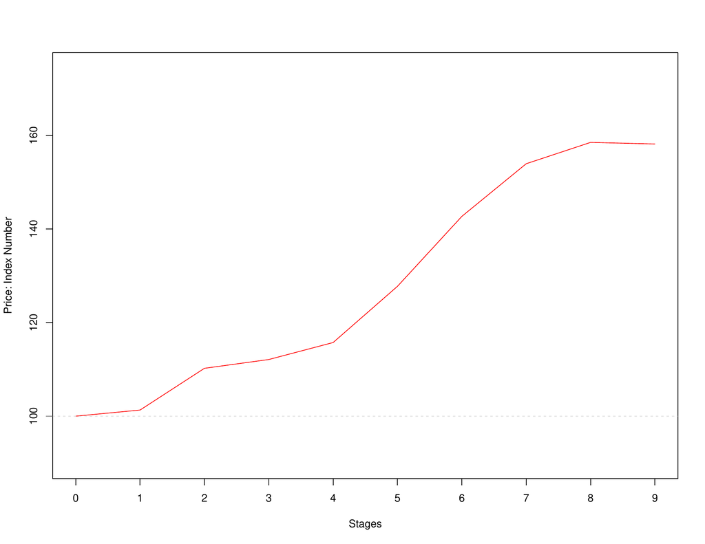

Figure 6: Laspeyres index evolution for the prices of several energy resources for the period 2005-2015.

**Paasche index in R**

Analogously, the joint evolution of magnitudes under the Paasche index (@ref(eq:niPaasche)) can be also determined by using *IndexNumber* package in R software. More specifically, `paasche.index.number()` provides the mentioned weighted index number. The results of the function follows a similar structure as the function previously mentioned, and using the same graphical and numerical options.

```r
paasche.index.number(ECResources[,2:6],ECResources[,7:11],
                     name="Price",opt.plot=TRUE,opt.summary=TRUE)
```

**Marshall-Edgeworth index in R**

The obtaining of the Marshall-Edgeworth index number (@ref(eq:niEdgeworth)) is also possible in R software through the use of *IndexNumber* package. In particular, we have to use the function `edgeworth.index.number()` with the above-mentioned options for obtaining graphics and summaries.

```r
edgeworth.index.number(ECResources[,2:6],ECResources[,7:11],
                       name="Price",opt.plot=FALSE,opt.summary=FALSE)
```

**Fisher index in R**

Here, we consider the case of determining the Fisher index (@ref(eq:niFisher)). In this case, `fisher.index.number()` provides a measure of the considered magnitude. Again, the options `opt.plot` and `opt.summary` allow the obtaining of additional information that may be of interest to the user.

```r
fisher.index.number(ECResources[,2:6],ECResources[,7:11],
                    name="Price",opt.plot=FALSE,opt.summary=FALSE)
```

**A complex index for $v$ in R**

The complex index for $v$ given in (@ref(eq:nivalue)) can be easily obtained as the Bradstreet-Dûtot index for the value in each instant of time. Recall that the value is obtained as the product of the amount of good by its price in each instant of time. Thus, the function `aggregated.index.number()` provides the value of this new index number as follows.

```r
aggregated.index.number(ECResources[,2:6]*ECResources[,7:11],
                        base="serie",type="BDutot",name="Prices",opt.plot=FALSE,
                        opt.summary=FALSE)
```

# Concluding Remarks

This paper discusses the implementation in R of classical index numbers used for comparing magnitudes mainly in economic contexts. Therefore, the *IndexNumber* package provides R users a set of functions to calculate index numbers. Concretely, this library allows the calculation of simple index numbers in series and in chain. Furthermore, complex index numbers are also implemented. In particular, the non-weigthed index numbers included are the Sauerbeck, Geometric mean, Harmonic mean, Bradstreet-Dûtot, Carli, Jevons, and Dûtot indexes; as weighted index numbers, the Laspeyres, Paasche, Marshall-Edgeworth, Fisher, and Bradstreet-Dûtot indexes were considered. Additionally, this package contains graphical tools in order to facilitate the results visualization and four real data sets that can be used as illustrative examples. Moreover, the use of this library could be easily combined with other classical packages focused on time series analysis. Future research and development plans for forthcoming versions of the package include the addition of new index numbers already considered in the literature that can be dealt with in the framework presented above. Of course, the corresponding graphical tools should also be implemented.

# Acknowledgments

A. Saavedra-Nieves acknowledges the financial support of FEDER/Ministerio de Ciencia, Innovación y Universidades - Agencia Estatal de Investigación under grant MTM2017-87197-C3-3-P. P. Saavedra-Nieves acknowledges the financial support of Ministerio de Economía y Competitividad of the Spanish government under grants MTM2016-76969-P and MTM2017-089422-P, and by the Xunta de Galicia through the European Regional Development Fund (Grupos de Referencia Competitiva ED431C-2017/38).

Allen, Roy George Douglas. 1982. *Index Numbers in Theory and Practice*. Springer. https://doi.org/10.4324/9780203788677.

Ang, Beng Wah, FL Liu, and Hyun-Sik Chung. 2004. “A Generalized Fisher Index Approach to Energy Decomposition Analysis.” *Energy Economics* 26 (5): 757–63. https://doi.org/10.1016/j.eneco.2004.02.002.

Barnett, William A. 1980. “Economic Monetary Aggregates an Application of Index Number and Aggregation Theory.” *Journal of Econometrics* 14 (1): 11–48. https://doi.org/10.1016/0304-4076(80)90070-6.

Bialek, Jacek. 2021. *PriceIndices: Calculating Bilateral and Multilateral Price Indexes*. https://CRAN.R-project.org/package=PriceIndices.

Białek, Jacek. 2012. “Proposition of a General Formula for Price Indices.” *Communications in Statistics-Theory and Methods* 41 (5): 943–52. https://doi.org/10.1080/03610926.2010.533238.

———. 2014. “Simulation Study of an Original Price Index Formula.” *Communications in Statistics-Simulation and Computation* 43 (2): 285–97. https://doi.org/10.1080/03610918.2012.700367.

Boyd, Gale A, and Joseph M Roop. 2004. “A Note on the Fisher Ideal Index Decomposition for Structural Change in Energy Intensity.” *The Energy Journal* 25 (1). https://doi.org/10.5547/ISSN0195-6574-EJ-Vol25-No1-5.

Boyle, GE. 1988. “The Economic Theory of Index Numbers: Empirical Tests for Volume Indices of Agricultural Output.” *Irish Journal of Agricultural Economics and Rural Sociology*, 1–20. https://www.jstor.org/stable/25556589.

Carli, G-R. 1804. “Del Valore e Della Proporzione Dei Metalli Monetati.” *Scrittori Classici Italiani Di Economia Politica* 13: 297–366.

Coggeshall, F. 1886. “The Arithmetic, Geometric, and Harmonic Means.” *The Quarterly Journal of Economics* 1 (1): 83–86. https://doi.org/10.2307/1883111.

Coyle, Barry T. 2007. “Aggregation of Price Risk over Commodities: An Economic Index Number Approach.” *American Journal of Agricultural Economics* 89 (4): 1085–97. https://doi.org/10.1111/j.1467-8276.2007.01023.x.

CPIManual. 2004. *Consumer Price Index Manual: Theory and Practice*. OECD, UN, Eurostat,; The World Bank by ILO, Geneva.

Danzon, Patricia M, and Li-Wei Chao. 2000. “Cross-National Price Differences for Pharmaceuticals: How Large, and Why?” *Journal of Health Economics* 19 (2): 159–95. https://doi.org/10.1016/S0167-6296(99)00039-9.

Diewert, W Erwin, and Alice O Nakamura. 2007. “The Measurement of Productivity for Nations.” *Handbook of Econometrics* 6: 4501–86. https://doi.org/10.1016/S1573-4412(07)06066-7.

Dodge, Yadolah. 2008. *The Concise Encyclopedia of Statistics*. Springer Science & Business Media. https://doi.org/10.1007/978-0-387-32833-1.

Drobisch, MW. 1871. “Ueber Mittelgrössen Und Die Anwendbarkeit Derselben Auf Die Berechnung Des Steigens Und Sinkens Des Geldwerths.” *Berichte Der Mathematisch-Physicalischen Classe Der königlich Sächsischen Gesellschaft Der Wissenschaften* 1.

Dumagan, Jesus C. 2002. “Comparing the Superlative Törnqvist and Fisher Ideal Indexes.” *Economics Letters* 76 (2): 251–58. https://doi.org/10.1016/S0165-1765(02)00049-6.

Dûtot, Charles. 1754. *Reflexions Politiques Sur Les Finances, Et Le Commerce*. Vol. 2. les freres Vaillant [and] N. Prevost.

Edgeworth, Francis Y. 1887. “Measurement of Change in Value of Money i.” *First Memorandum Presented to the British Association for the Advancement of Science. Reprinted in His Papers Relating to Political Economy* 1: 198–259.

Evelyn, Sir GS. 1798. “An Account of Some Endeavours to Ascertain a Standard of Weight and Measure. Philos.” *Trans* 113.

Fisher, Irving. 1922. *The Making of Index Numbers: A Study of Their Varieties, Tests, and Reliability*. Vol. 1. Houghton Mifflin. https://doi.org/10.2307/1883934.

Fleetwood, William. 1707. *Chronicon Preciosum: Or, an Account of English Money: The Price of Corn, and Other Commodities, for the Last 600 Years. In a Letter to a Student in the University of Oxford*. Charles Harper.

Forsyth, FG, and Ronald F Fowler. 1981. “The Theory and Practice of Chain Price Index Numbers.” *Journal of the Royal Statistical Society: Series A (General)* 144 (2): 224–46. https://doi.org/10.2307/2981921.

Frisch, Ragnar. 1936. “Annual Survey of General Economic Theory: The Problem of Index Numbers.” *Econometrica: Journal of the Econometric Society*, 1–38. https://doi.org/10.2307/1907119.

Haan, Jan de, and Eddy Opperdoes. 1997. “Estimation of the Coffee Price Index Using Scanner Data: The Choice of the Micro Index.” In *Third Meeting of the Ottawa Group*, 16–18.

Henningsen, Arne. 2017. *micEconIndex: Price and Quantity Indices*. https://CRAN.R-project.org/package=micEconIndex.

Hill, Robert J. 1999. “Comparing Price Levels Across Countries Using Minimum-Spanning Trees.” *Review of Economics and Statistics* 81 (1): 135–42. https://doi.org/10.1162/003465399767923881.

———. 2006. “When Does Chaining Reduce the Paasche–Laspeyres Spread? An Application to Scanner Data.” *Review of Income and Wealth* 52 (2): 309–25.

Hill, Robert J, and Daniel Melser. 2008. “Hedonic Imputation and the Price Index Problem: An Application to Housing.” *Economic Inquiry* 46 (4): 593–609. http://doi.org/10.1111/j.1465-7295.2007.00110.x.

Ivancic, Lorraine, W Erwin Diewert, and Kevin J Fox. 2011. “Scanner Data, Time Aggregation and the Construction of Price Indexes.” *Journal of Econometrics* 161 (1): 24–35. https://doi.org/10.1016/j.jeconom.2010.09.003.

Jevons, W Stanley. 1865. “On the Variation of Prices and the Value of the Currency Since 1782.” *Journal of the Statistical Society of London* 28 (2): 294–320. https://doi.org/10.2307/2338419.

Jevons, William Stanley. 1863. *A Serious Fall in the Value of Gold Ascertained: And Its Social Effects Set Forth*. E. Stanford.

Kakwani, Nanak, and Robert J Hill. 2002. “Economic Theory of Spatial Cost of Living Indices with Application to Thailand.” *Journal of Public Economics* 86 (1): 71–97. https://doi.org/10.1016/S0047-2727(00)00174-2.

Kendall, M. G. 1977. *The Early History of Index Numbers*. Vol. II. Griffin, London: Studies in the History of Statistics; Probability. https://doi.org/10.2307/1402090.

Kendall, Maurice. 1969. “Studies in the History of Probability and Statistics, XXI. The Early History of Index Numbers.” *Revue de l’Institut International de Statistique*, 1–12. https://doi.org/10.2307/1402090.

Lamm, RM. 1980. “Index Numbers and Changes in Food Prices.” *Agricultural Economics Research* 32 (2): 41–43.

Laspeyres, E. 1864. “Hamburger Waarenpreise 1851–1863 Und Die Californisch-Australischen Goldentdeckungen Seit 1848.” *Jahrbücher für Nationalökonomie Und Statistik* 3 (1): 81–118.

Laspeyres, K. 1871. “IX. Die Berechnung Einer Mittleren Waarenpreissteigerung.” *Jahrbücher für Nationalökonomie Und Statistik* 16 (1): 296–318.

Lowe, Joseph. 1822. “The Present State of England in Regard to Agriculture.” *Trade & Finance*.

Marshall, Alfred. 1887. “Remedies for Fluctuations of General Prices.” *The Contemporary Review, 1866-1900* 51: 355–75.

O’Donnell, Christopher J. 2018. “Measures of Productivity Change.” In *Productivity and Efficiency Analysis*, 93–143. Springer. https://doi.org/10.1007/s11123-012-0311-1.

Paasche, Herrmann. 1874. “Ueber Die Preisentwicklung Der Letzten Jahre Nach Den Hamburger Börsennotirungen Jahrbücher für Nationalökonomie Und Statistik, 23.” S.

Palgrave, RHI. 1886. “Currency and Standard of Value in England, France and India and the Rates of Exchange Between These Countries.” *Memorandum Submitted to the Royal Commission on Depression of Trade and Industry*, 312–90.

Reinsdorf, Marshall B, W Erwin Diewert, and Christian Ehemann. 2002. “Additive Decompositions for Fisher, Törnqvist and Geometric Mean Indexes.” *Journal of Economic and Social Measurement* 28 (1-2): 51–61. http://dx.doi.org/10.3233/JEM-2003-0194.

Saavedra-Nieves, Alejandro, and Paula Saavedra-Nieves. 2021. *IndexNumber: Index Numbers in Social Sciences*.

Sauerbeck, Augustus. 1895. “Index Numbers of Prices.” *The Economic Journal* 5 (18): 161–74. https://doi.org/10.2307/2955755.

Su, Bin, and BW Ang. 2014. “Attribution of Changes in the Generalized Fisher Index with Application to Embodied Emission Studies.” *Energy* 69: 778–86. https://doi.org/10.1016/j.energy.2014.03.074.

Walsh, Correa Moylan. 1901. *The Measurement of General Exchange-Value*. Vol. 25. Macmillan.

White, Graham. 2021. *IndexNumR: Index Number Calculation*. https://CRAN.R-project.org/package=IndexNumR.

Zhen, Chen, Eric A Finkelstein, Shawn A Karns, Ephraim S Leibtag, and Chenhua Zhang. 2019. “Scanner Data-Based Panel Price Indexes.” *American Journal of Agricultural Economics* 101 (1): 311–29. http://doi.org/10.1093/ajae/aay032.

Zofı́o, José L, and Angel M Prieto. 2006. “Return to Dollar, Generalized Distance Function and the Fisher Productivity Index.” *Spanish Economic Review* 8 (2): 113–38. http://dx.doi.org/10.1007/s10108-006-9004-0.